# PEC1: Algorithm K-NN

Laura Sudupe Medinilla

5 de abril, 2021

# The kNN Algorithm

In this markdown we are going to learn about classification using k-NN. Unlike many classification algorithms, k-NN does not do any learning. It simply stores the training data verbatim. Unlabeled test examples are then matched to the most similar records in the training set usin a distance function, and the unlabeled example is assignaed the label of its neighbors.

The strengths and weaknesses of this algorithm are as follows:

| **Strengths** | **Weaknesses** |
| --- | --- |
| * Simple and effective | * Does not produce a model, which limits the ability to find novel insights in relationships among features |
| * Makes no assumptions about the underlying data distribution | * Slow classification phase |
| * Fast training phase | * Requires a large amount of memory |
|  | * Nominal features and missing data require additional processing |

# Step 1 - Collecting data

We will utilize the “Protein Secondary Structure” from the Brookhaven National Laboratory (USA).This data includes the protein secondary structures from 101 representative proteins.

# Step 2 - Exploring and preparing the data

We are going to take a look to our data with `str(amino)`.

```
'data.frame':   10000 obs. of  18 variables:
 $ V1 : chr  "S" "L" "L" "L" ...
 $ V2 : chr  "S" "L" "L" "L" ...
 $ V3 : chr  "P" "Q" "N" "N" ...
 $ V4 : chr  "F" "Y" "P" "A" ...
 $ V5 : chr  "S" "Y" "K" "K" ...
 $ V6 : chr  "Q" "G" "K" "G" ...
  [list output truncated]
```

The data is structured with 10000 sequences with 18 amino acids. We want to see which is the central amino acid structure type. The `table()` output indicates that 5557 aminos has **coil** structure, 1935 has **beta-sheet** structure and 2508 has **alpha-helix** structure.

```r
table(amino$V18)
```

```
   _    e    h
5557 1935 2508
```

We can label the data and check the structure porcentages with `prop.table()`

```r
amino$V18 <- factor(amino$V18, levels = c("_", "e", "h"),
              labels=c("coil","beta-sheet","alpha-sheet"))
round(prop.table(table(amino$V18)) * 100, digits = 1)
```

```
       coil  beta-sheet alpha-sheet
       55.6        19.4        25.1
```

## Data preparation

### Creating training and test datasets

We are going to divide our data into two portions: a training dataset that will be used to build the KNN model and a test dataset that will be used to estimate the predictive accuracy of the model.

```r
data <- cbind(amino_one_hot, amino[,ncol(amino)])
colnames(data)[ncol(data)] <- 'V341'

set.seed(123)

train_indx <- sample(x= 1:nrow(data),
                     size= 0.67*nrow(data),
                     replace=FALSE)

train_data <- data[train_indx,-ncol(data)]
test_data <- data[-train_indx,-ncol(data)]

train_label <- data[train_indx, ncol(data)]
test_label <- data[-train_indx, ncol(data)]
```

# Step 3 - Training a model on the data

For the classification, we will use a kNN implementation from the `class` package. We use the `knn()` function to classify the test data

```r
amino_test_pred <- knn(train= train_data, test= test_data,
                       cl=train_label, k=21)
```

The `knn()` function returns a factor vector of predicted labels for each of the examples in the test dataset, which we have assigned to `amino_test_pred`.

# Step 4 - Evaluating model performance

We need to evaluate how well the predicted classes in the `amino_test_pred` vector match up with the known values in the `test_label` vector. To these purpose, we can use the `CrossTable()` function. We will create a cross tabulation indicating the agreement between two vectors.

```r
CrossTable(x=test_label, y=amino_test_pred, prop.chisq=FALSE)
```

```
   Cell Contents
|-------------------------|
|                       N |
|           N / Row Total |
|           N / Col Total |
|         N / Table Total |
|-------------------------|


Total Observations in Table:  3300


             | amino_test_pred
  test_label |        coil |  beta-sheet | alpha-sheet |   Row Total |
-------------|-------------|-------------|-------------|-------------|
        coil |        1739 |          29 |          53 |        1821 |
             |       0.955 |       0.016 |       0.029 |       0.552 |
             |       0.589 |       0.271 |       0.218 |             |
             |       0.527 |       0.009 |       0.016 |             |
-------------|-------------|-------------|-------------|-------------|
  beta-sheet |         544 |          64 |          38 |         646 |
             |       0.842 |       0.099 |       0.059 |       0.196 |
             |       0.184 |       0.598 |       0.156 |             |
             |       0.165 |       0.019 |       0.012 |             |
-------------|-------------|-------------|-------------|-------------|
 alpha-sheet |         667 |          14 |         152 |         833 |
             |       0.801 |       0.017 |       0.182 |       0.252 |
             |       0.226 |       0.131 |       0.626 |             |
             |       0.202 |       0.004 |       0.046 |             |
-------------|-------------|-------------|-------------|-------------|
Column Total |        2950 |         107 |         243 |        3300 |
             |       0.894 |       0.032 |       0.074 |             |
-------------|-------------|-------------|-------------|-------------|
```

# Step 5 - Improving the model performance

We will try several different values for **k**, (k = 1, 3, 5, 7, 11), to examine the performance. Using the previous test and training datasets, the same records were classified. The number of false negatives and false positives are shown for each iteration.

| k value | # false negatives | # false positives | % classified Incorrectly |
| --- | --- | --- | --- |
| 1 | 169 | 115 | 8.606061 |
| 3 | 292 | 135 | 12.939394 |
| 5 | 349 | 131 | 14.545454 |
| 7 | 395 | 110 | 15.303030 |
| 11 | 449 | 85 | 16.181818 |

Let’s see some other values

```r
confusionMatrix(amino_test_pred, test_label, positive = "coil" )
```

[output not shown]

The kappa value adjusts accuracy by acounting for the possibility of a correct prediction by chance alone. We have a fair agreement kappa value, and big error rate, these indicated us the proportion of the incorrectly classified examples.

# Step 7 - Prove our KNN classifier with different labels

We know the alpha-helix and beta-sheet are both non-coil structures. We are going to performe the same algorithm for these labels.

```r
data_coil <- cbind(amino_one_hot, amino[,ncol(amino)])
colnames(data_coil)[ncol(data_coil)] <- 'V341'

data_coil$V341 <- factor(data_coil$V341, levels = c( "beta-sheet", "alpha-sheet", "coil"),
              labels=c("no-coil","no-coil","coil"))
```

```r
table(data_coil$V341)
```

```
no-coil    coil
   4443    5557
```

## Creating training and test datasets

We are going to divide our data into two portions: a training dataset that will be used to build the KNN model and a test dataset that will be used to estimate the predictive accuracy of the model.

```r
train_indx_coil <- sample(x= 1:nrow(data_coil),
                     size= 0.67*nrow(data_coil),
                     replace=FALSE)

train_data_coil <- data_coil[train_indx_coil,-ncol(data_coil)]
test_data_coil <- data_coil[-train_indx_coil,-ncol(data_coil)]


train_label_coil <- data_coil[train_indx_coil, ncol(data_coil)]
test_label_coil <- data_coil[-train_indx_coil, ncol(data_coil)]
```

The Receiver Operating Characteristic curve is used to examine the trade-off between the detection of true positives, whiile avoiding the false positives. we are goint to calculate de AUC from all the k-s

```r
# ROC and AUC for k=1
aminocoil_test_pred1 <- knn(train = train_data_coil, test = test_data_coil, cl = train_label_coil, k=1,prob = TRUE)
prob1 <- attr(aminocoil_test_pred1, "prob")
prob1 <- ifelse(aminocoil_test_pred1 == "coil", 1-prob1, prob1) - 1
labels1 <- factor(test_label_coil, labels = c(0,1))

roc1 <- pROC::roc(labels1, prob1, auc= TRUE, ci=TRUE)
# ROC and AUC for k=3
aminocoil_test_pred3 <- knn(train = train_data_coil, test = test_data_coil, cl = train_label_coil, k=3,prob = TRUE)
prob3 <- attr(aminocoil_test_pred3, "prob")
prob3 <- ifelse(aminocoil_test_pred3 == "coil", 1-prob3, prob3) - 1
labels3 <- factor(test_label_coil, labels = c(0,1))

roc3 <- pROC::roc(labels3, prob3, auc= TRUE, ci=TRUE)
# ROC and AUC for k=5
aminocoil_test_pred5 <- knn(train = train_data_coil, test = test_data_coil, cl = train_label_coil, k=5,prob = TRUE)
prob5 <- attr(aminocoil_test_pred5, "prob")
prob5 <- ifelse(aminocoil_test_pred5 == "coil", 1-prob5, prob5) - 1
labels5 <- factor(test_label_coil, labels = c(0,1))

roc5 <- pROC::roc(labels5, prob5, auc= TRUE, ci=TRUE)
# ROC and AUC for k=7
aminocoil_test_pred7 <- knn(train = train_data_coil, test = test_data_coil, cl = train_label_coil, k=7,prob = TRUE)
prob7 <- attr(aminocoil_test_pred7, "prob")
prob7 <- ifelse(aminocoil_test_pred7 == "coil", 1-prob7, prob7) - 1
labels7 <- factor(test_label_coil, labels = c(0,1))

roc7 <- pROC::roc(labels7, prob7, auc= TRUE, ci=TRUE)
# ROC and AUC for k=11
aminocoil_test_pred11 <- knn(train = train_data_coil, test = test_data_coil, cl = train_label_coil, k=11,prob = TRUE)
prob11 <- attr(aminocoil_test_pred11, "prob")
prob11 <- ifelse(aminocoil_test_pred11 == "coil", 1-prob11, prob11) - 1
labels11 <- factor(test_label_coil, labels = c(0,1))

roc11 <- pROC::roc(labels11, prob11, auc= TRUE, ci=TRUE)
```

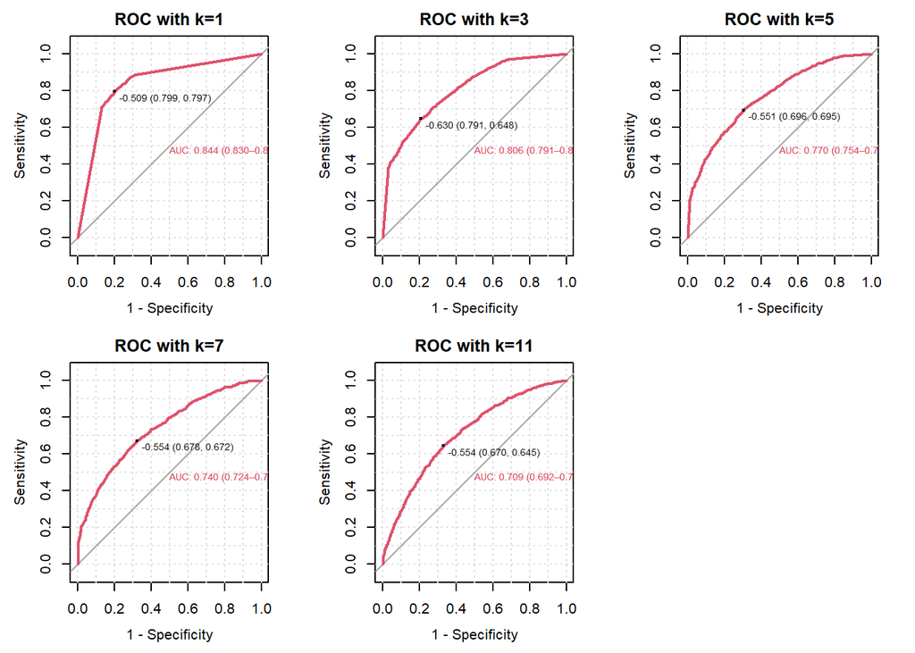

The perfect classifier has a curve that passes through the point at a 100 percent true positive rate and 0 percent false positive rate. The closer the curve is to the perfect classifier, the better it is at identifying positive values. This measured using a statistic known as the *area under the ROC curve* (abbreviated *AUC*). The best AUC value it was 1NN classifier, next 3NN and the others are similar between them.

| k value | # false negatives | # false positives | % classified Incorrectly |
| --- | --- | --- | --- |
| 1 | 338 | 333 | 20.33333 |
| 3 | 433 | 513 | 28.66667 |
| 5 | 459 | 559 | 30.84848 |
| 7 | 456 | 624 | 32.72727 |
| 11 | 447 | 689 | 34.42424 |